# Part I - Prosper Loan Data

## Introduction

> This data set contains 113,937 loans with 81 variables on each loan, including loan amount, borrower rate (or interest rate), current loan status, borrower income, and many others

## Preliminary Wrangling

We'll select only the feature of Interrest in the 81 features inside the DataSet

```python
# import all packages and set plots to be embedded inline
import numpy as np
import pandas as pd
import matplotlib.pyplot as plt
import seaborn as sb

%matplotlib inline
```

> Load in your dataset and describe its properties through the questions below. Try and motivate your exploration goals through this section.

```python
#Import the dataset into pandas
loan = pd.read_csv('prosperLoanData.csv');
#Display some useful info
print(loan.shape);
print(loan.head(5));
```

```
(113937, 81)
                ListingKey  ListingNumber            ListingCreationDate  \
0  1021339766868145413AB3B         193129  2007-08-26 19:09:29.263000000
1  10273602499503308B223C1        1209647  2014-02-27 08:28:07.900000000
2  0EE9337825851032864889A          81716  2007-01-05 15:00:47.090000000
3  0EF5356002482715299901A         658116  2012-10-22 11:02:35.010000000
4  0F023589499656230C5E3E2         909464  2013-09-14 18:38:39.097000000

  CreditGrade  Term LoanStatus           ClosedDate  BorrowerAPR  \
0           C    36  Completed  2009-08-14 00:00:00      0.16516
1         NaN    36    Current                  NaN      0.12016
2          HR    36  Completed  2009-12-17 00:00:00      0.28269
3         NaN    36    Current                  NaN      0.12528
4         NaN    36    Current                  NaN      0.24614

```

[output cut: 29 more lines]

### What is the structure of your dataset?

> The Dataset contains 113937 Rowns and 81 Columns

### What is/are the main feature(s) of interest in your dataset?

> The main features of interest are : LoanStatus; BorrowerAPR; BorrowerRate; ProsperRating (numeric); ProsperRating (Alpha); ProsperScore; Occupation; EmploymentStatus;IncomeVerifiable; StatedMonthlyIncome; TotalProsperLoans; LoanOriginalAmount

### What features in the dataset do you think will help support your investigation into your feature(s) of interest?

> The main features of interest are : LoanStatus; BorrowerAPR; BorrowerRate; EstimatedEffectiveYield; EstimatedLoss; EstimatedReturn; ProsperRating (numeric); ProsperRating (Alpha); ProsperScore; Term; Occupation; EmploymentStatus; EmploymentStatusDuration; AmountDelinquent; IncomeVerifiable; StatedMonthlyIncome; TotalProsperLoans; MonthlyLoanPayment

```python
#Selecting the colums of interest
cols_sub = ['LoanStatus', 'BorrowerAPR', 'BorrowerRate', 'EstimatedEffectiveYield',
              'EstimatedLoss', 'EstimatedReturn', 'ProsperRating (numeric)', 'ProsperRating (Alpha)',
              'ProsperScore', 'Term', 'Occupation', 'EmploymentStatus', 'EmploymentStatusDuration',
              'AmountDelinquent', 'IncomeVerifiable', 'StatedMonthlyIncome', 'TotalProsperLoans',
              'MonthlyLoanPayment','Recommendations', 'BorrowerState','LoanOriginalAmount',
            'IsBorrowerHomeowner'];

#Extracting only the above columns
loan_sub = pd.DataFrame(loan, columns=cols_sub);
#print the shape of dataset sub
print(loan_sub.shape);
```

```
(113937, 22)
```

```python
#Display the dataframe info
loan_sub.info()
```

```
<class 'pandas.core.frame.DataFrame'>
RangeIndex: 113937 entries, 0 to 113936
Data columns (total 22 columns):
LoanStatus                  113937 non-null object
BorrowerAPR                 113912 non-null float64
BorrowerRate                113937 non-null float64
EstimatedEffectiveYield     84853 non-null float64
EstimatedLoss               84853 non-null float64
EstimatedReturn             84853 non-null float64
ProsperRating (numeric)     84853 non-null float64
ProsperRating (Alpha)       84853 non-null object
ProsperScore                84853 non-null float64
Term                        113937 non-null int64
Occupation                  110349 non-null object
EmploymentStatus            111682 non-null object
EmploymentStatusDuration    106312 non-null float64
AmountDelinquent            106315 non-null float64
IncomeVerifiable            113937 non-null bool
StatedMonthlyIncome         113937 non-null float64
TotalProsperLoans           22085 non-null float64
MonthlyLoanPayment          113937 non-null float64
Recommendations             113937 non-null int64
BorrowerState               108422 non-null object
LoanOriginalAmount          113937 non-null int64
IsBorrowerHomeowner         113937 non-null bool
dtypes: bool(2), float64(12), int64(3), object(5)
memory usage: 17.6+ MB
```

```python
#Display some samples of the dataframe
loan_sub.head(30)
```

|  | LoanStatus | BorrowerAPR | BorrowerRate | EstimatedEffectiveYield | EstimatedLoss | EstimatedReturn | ProsperRating (numeric) | ProsperRating (Alpha) | ProsperScore | Term | ... | EmploymentStatusDuration | AmountDelinquent | IncomeVerifiable | StatedMonthlyIncome | TotalProsperLoans | MonthlyLoanPayment | Recommendations | BorrowerState | LoanOriginalAmount | IsBorrowerHomeowner |
| --- | --- | --- | --- | --- | --- | --- | --- | --- | --- | --- | --- | --- | --- | --- | --- | --- | --- | --- | --- | --- | --- |
| 0 | Completed | 0.16516 | 0.1580 | NaN | NaN | NaN | NaN | NaN | NaN | 36 | ... | 2.0 | 472.0 | True | 3083.333333 | NaN | 330.43 | 0 | CO | 9425 | True |
| 1 | Current | 0.12016 | 0.0920 | 0.07960 | 0.0249 | 0.05470 | 6.0 | A | 7.0 | 36 | ... | 44.0 | 0.0 | True | 6125.000000 | NaN | 318.93 | 0 | CO | 10000 | False |
| 2 | Completed | 0.28269 | 0.2750 | NaN | NaN | NaN | NaN | NaN | NaN | 36 | ... | NaN | NaN | True | 2083.333333 | NaN | 123.32 | 0 | GA | 3001 | False |
| 3 | Current | 0.12528 | 0.0974 | 0.08490 | 0.0249 | 0.06000 | 6.0 | A | 9.0 | 36 | ... | 113.0 | 10056.0 | True | 2875.000000 | NaN | 321.45 | 0 | GA | 10000 | True |
| 4 | Current | 0.24614 | 0.2085 | 0.18316 | 0.0925 | 0.09066 | 3.0 | D | 4.0 | 36 | ... | 44.0 | 0.0 | True | 9583.333333 | 1.0 | 563.97 | 0 | MN | 15000 | True |
| 5 | Current | 0.15425 | 0.1314 | 0.11567 | 0.0449 | 0.07077 | 5.0 | B | 10.0 | 60 | ... | 82.0 | 0.0 | True | 8333.333333 | NaN | 342.37 | 0 | NM | 15000 | True |
| 6 | Current | 0.31032 | 0.2712 | 0.23820 | 0.1275 | 0.11070 | 2.0 | E | 2.0 | 36 | ... | 172.0 | 0.0 | True | 2083.333333 | NaN | 122.67 | 0 | KS | 3000 | False |
| 7 | Current | 0.23939 | 0.2019 | 0.17830 | 0.0799 | 0.09840 | 4.0 | C | 4.0 | 36 | ... | 103.0 | 0.0 | True | 3355.750000 | NaN | 372.60 | 0 | CA | 10000 | False |
| 8 | Current | 0.07620 | 0.0629 | 0.05221 | 0.0099 | 0.04231 | 7.0 | AA | 9.0 | 36 | ... | 269.0 | 0.0 | True | 3333.333333 | NaN | 305.54 | 0 | IL | 10000 | True |
| 9 | Current | 0.07620 | 0.0629 | 0.05221 | 0.0099 | 0.04231 | 7.0 | AA | 11.0 | 36 | ... | 269.0 | 0.0 | True | 3333.333333 | NaN | 305.54 | 0 | IL | 10000 | True |
| 10 | Current | 0.27462 | 0.2489 | 0.23320 | 0.0890 | 0.14420 | 4.0 | C | 7.0 | 60 | ... | 300.0 | 253.0 | True | 7500.000000 | NaN | 395.37 | 0 | MD | 13500 | False |
| 11 | Completed | 0.15033 | 0.1325 | NaN | NaN | NaN | NaN | NaN | NaN | 36 | ... | 19.0 | 2224.0 | True | 1666.666667 | NaN | 33.81 | 0 | NaN | 1000 | False |
| 12 | Past Due (1-15 days) | 0.17969 | 0.1435 | 0.12640 | 0.0524 | 0.07400 | 5.0 | B | 4.0 | 36 | ... | 1.0 | 0.0 | True | 2416.666667 | NaN | 137.39 | 0 | AL | 4000 | False |
| 13 | Current | 0.13138 | 0.1034 | 0.09050 | 0.0274 | 0.06310 | 6.0 | A | 8.0 | 36 | ... | 98.0 | 0.0 | True | 5833.333333 | NaN | 275.63 | 0 | AZ | 8500 | True |
| 14 | Current | 0.11695 | 0.0949 | 0.08270 | 0.0224 | 0.06030 | 6.0 | A | 8.0 | 60 | ... | 35.0 | 0.0 | True | 10833.333333 | NaN | 415.37 | 0 | VA | 19330 | False |
| 15 | Defaulted | 0.35797 | 0.3177 | 0.28960 | 0.1650 | 0.12460 | 1.0 | HR | 5.0 | 36 | ... | 121.0 | 0.0 | True | 5500.000000 | NaN | 173.71 | 0 | FL | 4000 | True |
| 16 | Current | 0.30748 | 0.2809 | 0.24730 | 0.1225 | 0.12480 | 2.0 | E | 4.0 | 60 | ... | 133.0 | 2469.0 | True | 8291.666667 | 3.0 | 124.76 | 0 | CA | 4000 | True |
| 17 | Chargedoff | 0.13202 | 0.1250 | NaN | NaN | NaN | NaN | NaN | NaN | 36 | ... | NaN | NaN | True | 5833.333333 | NaN | 334.54 | 0 | NaN | 10000 | True |
| 18 | Current | 0.12528 | 0.0974 | 0.08490 | 0.0249 | 0.06000 | 6.0 | A | 7.0 | 36 | ... | 179.0 | 0.0 | True | 6250.000000 | NaN | 482.18 | 0 | PA | 15000 | False |
| 19 | Current | 0.24754 | 0.2225 | 0.19520 | 0.1025 | 0.09270 | 3.0 | D | 8.0 | 60 | ... | 18.0 | 0.0 | True | 3075.000000 | 1.0 | 180.45 | 0 | OR | 6500 | False |
| 20 | Current | 0.16732 | 0.1314 | 0.11567 | 0.0449 | 0.07077 | 5.0 | B | 7.0 | 36 | ... | 175.0 | 0.0 | True | 5166.666667 | NaN | 472.66 | 0 | MN | 14000 | True |
| 21 | Completed | 0.21488 | 0.2075 | NaN | NaN | NaN | NaN | NaN | NaN | 36 | ... | 36.0 | 5200.0 | True | 3750.000000 | NaN | 112.64 | 0 | MI | 3000 | False |
| 22 | Current | 0.35356 | 0.3134 | 0.27600 | 0.1575 | 0.11850 | 1.0 | HR | 2.0 | 36 | ... | 68.0 | 0.0 | True | 118.333333 | NaN | 172.76 | 0 | NY | 4000 | False |
| 23 | Defaulted | 0.28032 | 0.2419 | 0.21260 | 0.1075 | 0.10510 | 3.0 | D | 5.0 | 36 | ... | 3.0 | 0.0 | True | 2500.000000 | NaN | 78.67 | 0 | IL | 2000 | False |
| 24 | Current | 0.19859 | 0.1620 | 0.14256 | 0.0649 | 0.07766 | 4.0 | C | 5.0 | 36 | ... | 91.0 | 0.0 | True | 2333.333333 | NaN | 141.02 | 0 | LA | 4000 | True |
| 25 | Current | 0.30182 | 0.2629 | 0.23057 | 0.1275 | 0.10307 | 2.0 | E | 3.0 | 36 | ... | 15.0 | 0.0 | True | 6974.000000 | NaN | 161.78 | 0 | CA | 4000 | False |
| 26 | Completed | 0.30748 | 0.2809 | 0.24730 | 0.1225 | 0.12480 | 2.0 | E | 3.0 | 60 | ... | 25.0 | 0.0 | True | 3885.916667 | NaN | 124.76 | 0 | NY | 4000 | False |
| 27 | Completed | 0.11296 | 0.0920 | 0.06080 | 0.0210 | 0.06080 | 6.0 | A | 9.0 | 36 | ... | 10.0 | 0.0 | True | 6666.666667 | NaN | 0.00 | 0 | CO | 4000 | True |
| 28 | Current | 0.20268 | 0.1660 | 0.14661 | 0.0624 | 0.08421 | 4.0 | C | 4.0 | 36 | ... | 48.0 | 0.0 | True | 3600.000000 | NaN | 354.54 | 0 | PA | 10000 | True |
| 29 | Current | 0.15223 | 0.1239 | 0.10900 | 0.0399 | 0.06910 | 6.0 | A | 6.0 | 36 | ... | 16.0 | 0.0 | True | 10416.666667 | NaN | 1169.03 | 0 | LA | 35000 | True |

30 rows × 22 columns

```python
#Dispaly some statistic info
loan_sub.describe()
```

|  | BorrowerAPR | BorrowerRate | EstimatedEffectiveYield | EstimatedLoss | EstimatedReturn | ProsperRating (numeric) | ProsperScore | Term | EmploymentStatusDuration | AmountDelinquent | StatedMonthlyIncome | TotalProsperLoans | MonthlyLoanPayment | Recommendations | LoanOriginalAmount |
| --- | --- | --- | --- | --- | --- | --- | --- | --- | --- | --- | --- | --- | --- | --- | --- |
| count | 113912.000000 | 113937.000000 | 84853.000000 | 84853.000000 | 84853.000000 | 84853.000000 | 84853.000000 | 113937.000000 | 106312.000000 | 106315.000000 | 1.139370e+05 | 22085.000000 | 113937.000000 | 113937.000000 | 113937.00000 |
| mean | 0.218828 | 0.192764 | 0.168661 | 0.080306 | 0.096068 | 4.072243 | 5.950067 | 40.830248 | 96.071582 | 984.507059 | 5.608026e+03 | 1.421100 | 272.475783 | 0.048027 | 8337.01385 |
| std | 0.080364 | 0.074818 | 0.068467 | 0.046764 | 0.030403 | 1.673227 | 2.376501 | 10.436212 | 94.480605 | 7158.270157 | 7.478497e+03 | 0.764042 | 192.697812 | 0.332353 | 6245.80058 |
| min | 0.006530 | 0.000000 | -0.182700 | 0.004900 | -0.182700 | 1.000000 | 1.000000 | 12.000000 | 0.000000 | 0.000000 | 0.000000e+00 | 0.000000 | 0.000000 | 0.000000 | 1000.00000 |
| 25% | 0.156290 | 0.134000 | 0.115670 | 0.042400 | 0.074080 | 3.000000 | 4.000000 | 36.000000 | 26.000000 | 0.000000 | 3.200333e+03 | 1.000000 | 131.620000 | 0.000000 | 4000.00000 |
| 50% | 0.209760 | 0.184000 | 0.161500 | 0.072400 | 0.091700 | 4.000000 | 6.000000 | 36.000000 | 67.000000 | 0.000000 | 4.666667e+03 | 1.000000 | 217.740000 | 0.000000 | 6500.00000 |
| 75% | 0.283810 | 0.250000 | 0.224300 | 0.112000 | 0.116600 | 5.000000 | 8.000000 | 36.000000 | 137.000000 | 0.000000 | 6.825000e+03 | 2.000000 | 371.580000 | 0.000000 | 12000.00000 |
| max | 0.512290 | 0.497500 | 0.319900 | 0.366000 | 0.283700 | 7.000000 | 11.000000 | 60.000000 | 755.000000 | 463881.000000 | 1.750003e+06 | 8.000000 | 2251.510000 | 39.000000 | 35000.00000 |

# Variable Type :

**LoanStatus** : Categorical  
**BorrowerAPR** : Quantitative  
**BorrowerRate** : Quantitative  
**EstimatedEffectiveYield** : Quantitative  
**EstimatedLoss** : Quantitative  
**EstimatedReturn** : Quantitative  
**ProsperRating (numeric)** : Quantitative  
**ProsperRating (Alpha)** : Categorical  
**ProsperScore** : Categorical  
**Term** : Quantitative  
**Occupation** : Categorical  
**EmploymentStatus** : Categorical  
**EmploymentStatusDuration** : Quantitative  
**AmountDelinquent** : Quantitative  
**IncomeVerifiable** : Categorical  
**StatedMonthlyIncome** : Quantitative  
**TotalProsperLoans** : Quantitative  
**MonthlyLoanPayment** : Quantitative  
**Recommendations** : Quantitative  
**BorrowerState** : Categorical

## Univariate Exploration

> In this section, investigate distributions of individual variables. If you see unusual points or outliers, take a deeper look to clean things up and prepare yourself to look at relationships between variables.

> **Rubric Tip**: The project (Parts I alone) should have at least 15 visualizations distributed over univariate, bivariate, and multivariate plots to explore many relationships in the data set. Use reasoning to justify the flow of the exploration.

> **Rubric Tip**: Use the "Question-Visualization-Observations" framework throughout the exploration. This framework involves **asking a question from the data, creating a visualization to find answers, and then recording observations after each visualisation.**

### Visualization 1 : Univariate "LoanStatus"

Question : What is the LoanStatus Distribution in the Dataset ?

```python
#Function to change size of the graph
def Resize(a,b):
    from matplotlib import rcParams
    rcParams['figure.figsize'] = a,b
```

```python
#Function to plot the Labels
def labels(x,y,t):
    plt.xlabel(x);
    plt.ylabel(y);
    plt.title(t);
    plt.show();
```

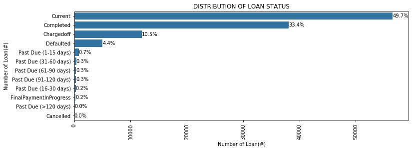

```python
#Calling the function Resize
Resize(12,4);

#Plot the 1st Univariate Visualization
type_order = loan_sub['LoanStatus'].value_counts().index;
sb.countplot(data=loan_sub, y='LoanStatus', color=sb.color_palette()[0], order=type_order);
plt.xticks(rotation=90);

#DIsplay the percentages of LoanStatus
NB=loan_sub['LoanStatus'].value_counts().sum() #Denominator for the rate calculation
status_count= loan_sub['LoanStatus'].value_counts();
for i in range (status_count.shape[0]):
    count = status_count[i]
    pct_string = '{:0.1f}%'.format(100*count/NB)
    plt.text(count+1, i, pct_string, va='center')

#Call the labels function
labels("Number of Loan(#)","Number of Loan(#)","DISTRIBUTION OF LOAN STATUS")
```

Findings : **49.7%** of Loan are **Current**, **33.4%** of Loan are **Completed**, **4.4%** of Loan are **Defaulted**

> **Rubric Tip**: Visualizations should depict the data appropriately so that the plots are easily interpretable. You should choose an appropriate plot type, data encodings, and formatting as needed. The formatting may include setting/adding the title, labels, legend, and comments. Also, do not overplot or incorrectly plot ordinal data.

### Visualization 2 : Univariate "ProsperRating (Alpha)"

Question : What is the PropsperRating(Alpha) Distribution in the Dataset ?

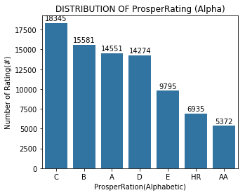

```python
#Calling the function Resize
Resize(5,4);

#Plot the 1st Univariate Visualization
type_order = loan_sub['ProsperRating (Alpha)'].value_counts().index;
sb.countplot(data=loan_sub, x='ProsperRating (Alpha)', color=sb.color_palette()[0], order=type_order);

#Plotting count values
for i in range (loan_sub['ProsperRating (Alpha)'].value_counts().shape[0]):
    count = loan_sub['ProsperRating (Alpha)'].value_counts().values[i]
    plt.text(i, count+1000, count, ha = 'center', va='top')

#Call the labels function
labels("ProsperRation(Alphabetic)","Number of Rating(#)","DISTRIBUTION OF ProsperRating (Alpha)")
```

Findings : The Most used PropserRating are : **C, B** and **A**

### Visualization 3 : Univariate "Term"

Question : What is the Term Distribution in the Dataset ?

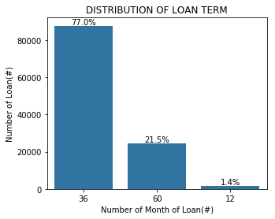

```python
#Resizing the plot
Resize(5,4);

#Plot the 1st Univariate Visualization
type_order = loan_sub['Term'].value_counts().index;
sb.countplot(data=loan_sub, x='Term', color=sb.color_palette()[0], order=type_order);

#Plotting the percentages
NB=loan_sub['Term'].value_counts().sum();
for i in range (loan_sub['Term'].value_counts().shape[0]):
    count = loan_sub['Term'].value_counts().values[i]
    pct_string = '{:0.1f}%'.format(100*count/NB)
    plt.text(i, count+4000, pct_string, ha = 'center', va='top')

#Call the labels function
labels("Number of Month of Loan(#)","Number of Loan(#)","DISTRIBUTION OF LOAN TERM")
```

Findings : **77%** of Loan Term is **36 Months**; **21.5%** is **60 months** and **1.4%** is **12 months**

### Visualization 4 : Univariate "Occupation"

Question : What is the Occupation of the Loan Borrowers ?

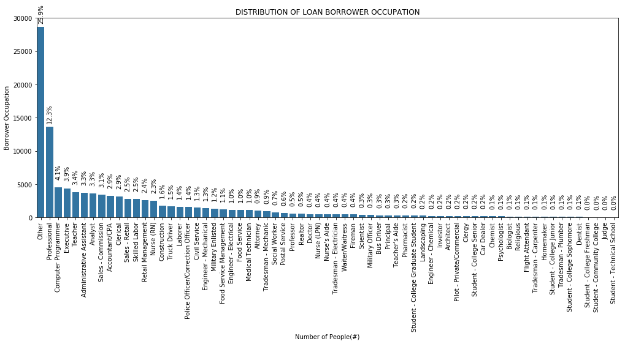

```python
#Adjusting the size
Resize(17,6);

#Plot the 1st Univariate Visualization
type_order = loan_sub['Occupation'].value_counts().index;
sb.countplot(data=loan_sub, x='Occupation', color=sb.color_palette()[0], order=type_order);
plt.xticks(rotation=90);

#Plotting labels
NB=loan_sub['Occupation'].value_counts().sum();
for i in range (loan_sub['Occupation'].value_counts().shape[0]):
    count = loan_sub['Occupation'].value_counts().values[i]
    pct_string = '{:0.1f}%'.format(100*count/NB)
    plt.text(i, count+3500, pct_string, ha = 'center', va='top', rotation=90)

#Call the labels function
labels("Number of People(#)","Borrower Occupation","DISTRIBUTION OF LOAN BORROWER OCCUPATION")
```

Finding : **12.3%** are **Professionals**; **4.1%** are **Computer programmers** and **25.9%** have different occupation than the most common

### Visualization 5 : Univariate "Borrower Rate"

Question : What is the Borrower Rate repartition ?

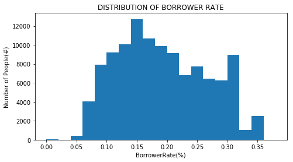

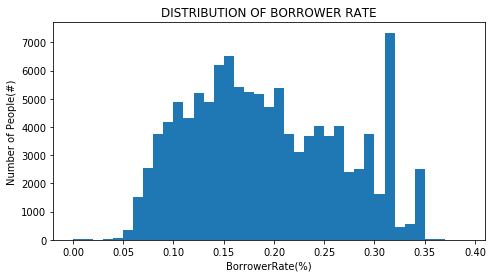

```python
#Calling Resize function
Resize(17,4);

#Plot the  Visualization in the 1st subplot
plt.subplot(1, 2, 1)
bins = np.arange(0, 0.4, 1/50)
plt.hist(data=loan_sub, x='BorrowerRate', bins=bins, color=sb.color_palette()[0]);
labels("BorrowerRate(%)","Number of People(#)","DISTRIBUTION OF BORROWER RATE")
#Plot un onother Subplot
plt.subplot(1, 2, 2)
bins = np.arange(0, 0.4, 1/100)
plt.hist(data=loan_sub, x='BorrowerRate', bins=bins, color=sb.color_palette()[0]);
#Call the labels function
labels("BorrowerRate(%)","Number of People(#)","DISTRIBUTION OF BORROWER RATE")
```

Findings : Most of the Borrowers rate is between **0.10** and **0.20**

### Visualization 6 : Univariate "BorrowerState"

Question : From which state are the Borrowers from ?

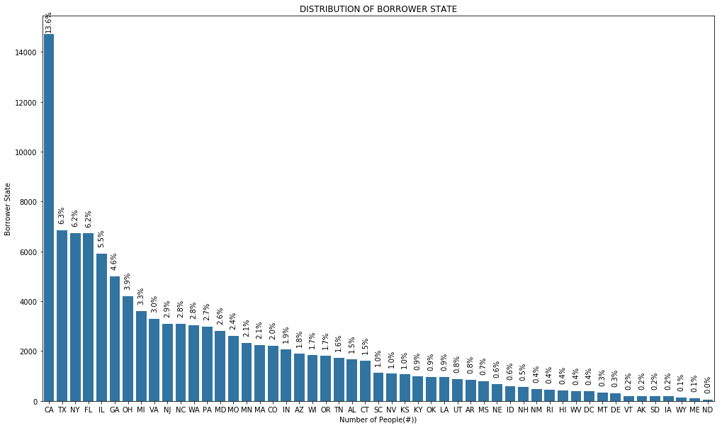

```python
#Adjusting the size
Resize(17,10);

#Plot the 1st Univariate Visualization
type_order = loan_sub['BorrowerState'].value_counts().index;
sb.countplot(data=loan_sub, x='BorrowerState', color=sb.color_palette()[0], order=type_order);

#Plotting labels
NB=loan_sub['BorrowerState'].value_counts().sum();
for i in range (loan_sub['BorrowerState'].value_counts().shape[0]):
    count = loan_sub['BorrowerState'].value_counts().values[i]
    pct_string = '{:0.1f}%'.format(100*count/NB)
    plt.text(i, count+1000, pct_string, ha = 'center', va='top', rotation=90)

#Call the labels function
labels("Number of People(#))","Borrower State","DISTRIBUTION OF BORROWER STATE")
```

Findings : **California** is the leading state from which the Borrowers are coming from.  
The top 5 States with more Borrowers are : **California, Texas, New York, Florida, Illinois**

### Visualization 7 : Univariate "MonthlyLoanPayment"

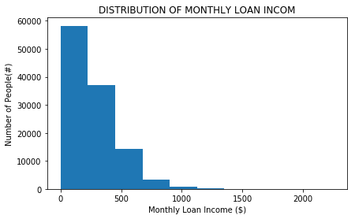

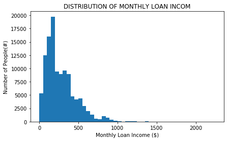

```python
#Calling Resize function
Resize(15,4);

#Plot the  Visualization in the 1st subplot
plt.subplot(1, 2, 1)
bins = np.arange(0, loan_sub['MonthlyLoanPayment'].max(), 100)
plt.hist(data=loan_sub, x='MonthlyLoanPayment');
#Call the labels function
labels("Monthly Loan Income ($)","Number of People(#)","DISTRIBUTION OF MONTHLY LOAN INCOM")

#Plot un onother Subplot
plt.subplot(1, 2, 2)
bins = np.arange(0, loan_sub['MonthlyLoanPayment'].max(), 50)
plt.hist(data=loan_sub, x='MonthlyLoanPayment', bins=bins);
#Call the labels function
labels("Monthly Loan Income ($)","Number of People(#)","DISTRIBUTION OF MONTHLY LOAN INCOM")
```

### Visualization 8 : Univariate "EmploymentStatus"

What is the Employment Status of the differetn Borrowers ?

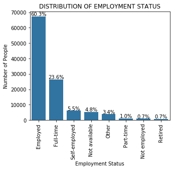

```python
#Adjusting the size
Resize(5,4);

#Plot the 1st Univariate Visualization
type_order = loan_sub['EmploymentStatus'].value_counts().index;
sb.countplot(data=loan_sub, x='EmploymentStatus', color=sb.color_palette()[0], order=type_order);
plt.xticks(rotation=90);

#Plotting labels
NB=loan_sub['EmploymentStatus'].value_counts().sum() #Denominator for the rate calculation
for i in range (loan_sub['EmploymentStatus'].value_counts().shape[0]):
    count = loan_sub['EmploymentStatus'].value_counts().values[i]
    pct_string = '{:0.1f}%'.format(100*count/NB)
    plt.text(i, count+3000, pct_string, ha = 'center', va='top')

#Call the labels function
labels("Employment Status","Number of People","DISTRIBUTION OF EMPLOYMENT STATUS")
```

Findings : **60.3%** of the Borrowers are **Employed**, **0.7%** are **Not Employed** and **5.5%** are **Self-Employed**

### Visualization 9 : Univariate "IncomeVerifiable"

Question: Is the Income Verifiable for the different Borrowers ?

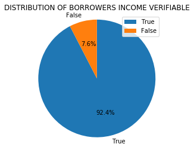

```python
#Plotting a Pir Chart
sorted_counts = loan_sub['IncomeVerifiable'].value_counts();
plt.pie(sorted_counts, labels=sorted_counts.index, startangle=90, counterclock=False, autopct='%1.1f%%')
plt.axis('square');
plt.legend();
plt.title('DISTRIBUTION OF BORROWERS INCOME VERIFIABLE');
```

Findings : Income is verifiable for **92.4%** of the Borrowers

### Visualization 10 : Univariate "LoanOriginalAmount"

Question : What is the Original Loan Amount ?

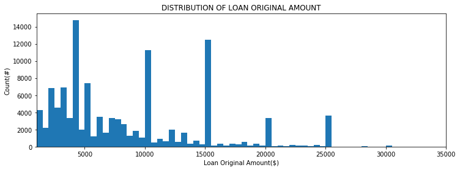

```python
#Adjusting the size
Resize(12,4);

# plot the loan original amount against a log scale because it has a long tail
bins = np.arange(0, loan_sub['LoanOriginalAmount'].max(), 500)
plt.hist(data = loan_sub, x = 'LoanOriginalAmount', bins=bins, color=sb.color_palette()[0])
plt.xlim((1000,35000))

#Call the labels function
labels("Loan Original Amount($)","Count(#)","DISTRIBUTION OF LOAN ORIGINAL AMOUNT")
```

Findings : The Loan Original Amount is between **1000** and **10000** for the majority

Question : What is the Relationship between the variable ?  
'LoanOriginalAmount', 'StatedMonthlyIncome', 'BorrowerAPR', 'MonthlyLoanPayment','BorrowerRate'

```python
# Some useful variables
my_vars = ['LoanOriginalAmount', 'StatedMonthlyIncome', 'BorrowerAPR', 'MonthlyLoanPayment','BorrowerRate' ]
```

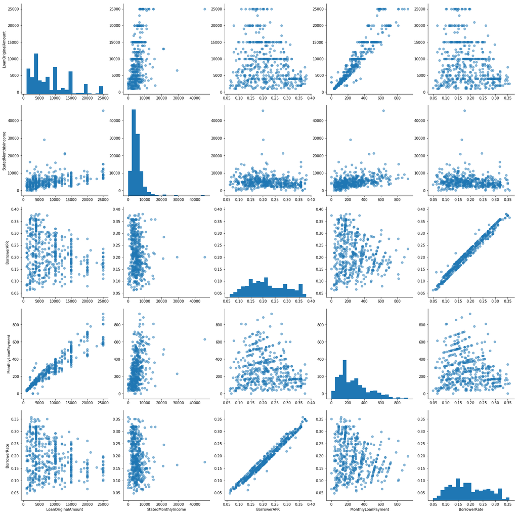

```python
# Choose fixed 500 random samples
samp = np.random.choice(loan_sub.shape[0], 500, replace = False)
loan_samp = loan_sub.reindex(samp)

# plot the pair grid
g = sb.PairGrid(data = loan_samp, vars = my_vars, size = 4)
g = g.map_diag(plt.hist, bins = 20)
g.map_offdiag(plt.scatter, alpha = 1/2);
```

### Of the features you investigated, were there any unusual distributions? Did you perform any operations on the data to tidy, adjust, or change the form of the data? If so, why did you do this?

> No need to perform additional transformations

## Bivariate Exploration

> In this section, investigate relationships between pairs of variables in your data. Make sure the variables that you cover here have been introduced in some fashion in the previous section (univariate exploration).

### Visualization 11 : Bivariate 'LoanOriginalAmount' VS 'MonthlyLoanPayment'

Question : What is the relation between **LoanOriginalAmount** and **MonthlyLoanPayment** ?

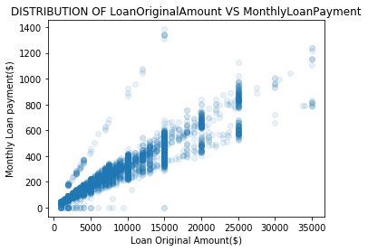

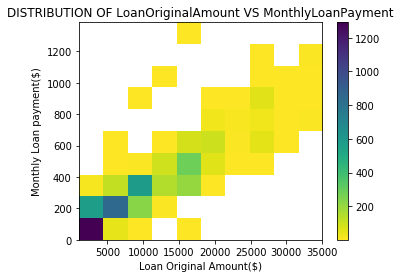

```python
#Randomly select some samples
np.random.seed(1)
loan_samples = loan_sub.sample(5000)
# PLOT ON LEFT
plt.subplot(1, 2, 1)
sb.regplot(data=loan_samples, x = 'LoanOriginalAmount', y = 'MonthlyLoanPayment', fit_reg=False, x_jitter=0.04,
           scatter_kws={'alpha':1/10});
#Call the labels function
labels("Loan Original Amount($)","Monthly Loan payment($)","DISTRIBUTION OF LoanOriginalAmount VS MonthlyLoanPayment")

# PLOT ON RIGHT
plt.subplot(1, 2, 2)
plt.hist2d(data=loan_samples, x = 'LoanOriginalAmount', y = 'MonthlyLoanPayment', cmin=0.5, cmap='viridis_r')
plt.colorbar()
#Call the labels function
labels("Loan Original Amount($)","Monthly Loan payment($)","DISTRIBUTION OF LoanOriginalAmount VS MonthlyLoanPayment")
```

Findings : There is a **positive correlation** Line between **LoanOriginalAmount** and **MonthlyLoanPayment**

### Visualization 12 : Bivariate 'BorrowerState' VS 'StatedMonthlyIncome'

Queqtion : What is the relationship between **BorrowerState** and **StateMonthlyIncome**

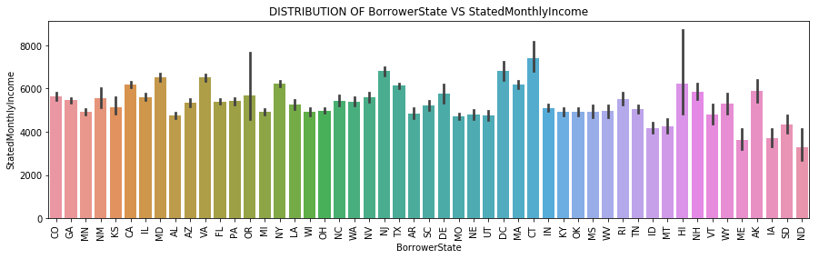

```python
#Adjusting the size
Resize(15,4);

sb.barplot(x='BorrowerState', y='StatedMonthlyIncome', data=loan_sub)
plt.xticks(rotation=90);
plt.title('DISTRIBUTION OF BorrowerState VS StatedMonthlyIncome');
#Call the labels function
labels("BorrowerState","StatedMonthlyIncome","DISTRIBUTION OF BorrowerState VS StatedMonthlyIncome")
```

Findings : The **StateMonthlyIncome** is around **5000 dollars** for most of the States

### Visualization 13 : Bivariate 'BorrowerAPR' VS 'BorrowerRate'

What is the Relationship between **BorrowerAPR** and **BorrowerRate** ?

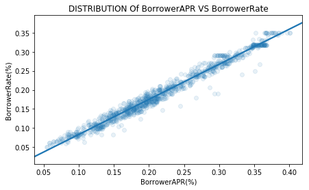

```python
#Adjusting the size
Resize(7,4);

#Randomly select some samples
np.random.seed(1)
loan_samples = loan_sub.sample(1000)

#Plot a scatter plot
sb.regplot(data=loan_samples, x = 'BorrowerAPR', y = 'BorrowerRate', fit_reg=True, x_jitter=0.01,
           scatter_kws={'alpha':1/10});
plt.title('DISTRIBUTION OF BorrowerAPR VS BorrowerRate');

#Call the labels function
labels("BorrowerAPR(%)","BorrowerRate(%)","DISTRIBUTION Of BorrowerAPR VS BorrowerRate")
```

Findings : There is a **Strong positive** correlation between **BorrowerAPR** and **BorrowerRate**

### Talk about some of the relationships you observed in this part of the investigation. How did the feature(s) of interest vary with other features in the dataset?

> There is a **positive correlation** Line between **LoanOriginalAmount** and **MonthlyLoanPayment**  
> The **StateMonthlyIncome** is around **5000 dollars** for most of the States  
> There is a **Strong positive** correlation between **BorrowerAPR** and **BorrowerRate**

## Multivariate Exploration

> Create plots of three or more variables to investigate your data even further. Make sure that your investigations are justified, and follow from your work in the previous sections.

### Visualization 14 : Multivariate 'ProsperScore' VS 'BorrowerRate' and 'Term'

What is the relation between the 3 variables : **ProsperScore** VS **BorrowerRate** and **Term** ?

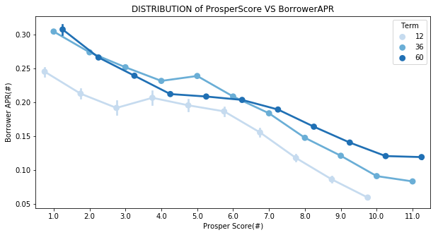

```python
#plot pointplot
fig = plt.figure(figsize = [10,5])
ax = sb.pointplot(data = loan_sub, x = 'ProsperScore', y = 'BorrowerRate', hue = 'Term',
           palette = 'Blues', linestyles = '-',dodge = 0.5)

#Call the labels function
labels("Prosper Score(#)","Borrower APR(#)","DISTRIBUTION of ProsperScore VS BorrowerAPR");
```

Findings : There is a **negative correlation** bewteen the **BorrowerRate** and **ProsperScore**.  
This negative correlation is different for each Loan **Term**

What is the relationship between the 3 variable : **LoanOriginalAmount**, **MonthlyLoanPayment** and **Term**

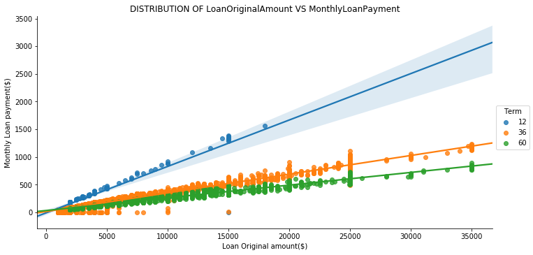

```python
#Randomly select some samples
np.random.seed(5)
loan_samples = loan_sub.sample(10000)

# Scatter Plot with Hue=Term
sb.lmplot(data=loan_samples, x = 'LoanOriginalAmount', y = 'MonthlyLoanPayment', hue='Term', size=5, aspect=2);

#Call the labels function
labels("Loan Original amount($)","Monthly Loan payment($)","DISTRIBUTION OF LoanOriginalAmount VS MonthlyLoanPayment");
```

Findings : There is a positive Correlation for each value of **Term** bewteen **LoanOriginalAmount** and **MonthlyLoanPayment**

### Visualization 16 : Multivariate 'ProsperScore' VS 'BorrowerRate' and 'IsBorrowerHomeowner'

What is the relationship between **ProsperScore** VS **BorrowerRate** and **IsBorrowerHomeowner**

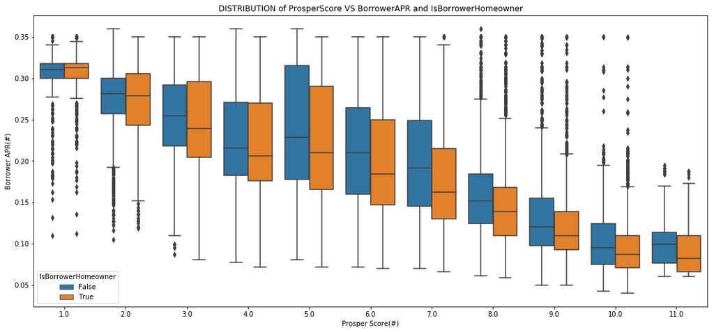

```python
#Set the figure size
plt.figure(figsize = [18, 8])
#Plot a Boxplot
sb.boxplot(data=loan_sub, x='ProsperScore', y='BorrowerRate', hue='IsBorrowerHomeowner');

#Call the labels function
labels("Prosper Score(#)","Borrower APR(#)","DISTRIBUTION of ProsperScore VS BorrowerAPR and IsBorrowerHomeowner");
```

Findings : There is a negative correlation between **BorrowerRate** and **ProsperScore**.  
This negative correlation if different if the Borrower is Owner or Not

### Talk about some of the relationships you observed in this part of the investigation. Were there features that strengthened each other in terms of looking at your feature(s) of interest?

> There is a **negative correlation** bewteen the **BorrowerRate** and **ProsperScore**.This negative correlation is different for each Loan **Term**  
> There is a positive Correlation for each value of **Term** bewteen **LoanOriginalAmount** and **MonthlyLoanPayment**  
> There is a negative correlation between **BorrowerRate** and **ProsperScore**.This negative correlation if different if the Borrower is Owner or Not

### Were there any interesting or surprising interactions between features?

> Yes. The impat of Loan **Term** in the different correlation like **LoanOriginalAmount** and **MonthlyLoanPayments**